# EP10-Estadistica

Equipo 4

29-07-2026

# Contexto

Un estudio recolectó medidas anatómicas de 247 hombres y 260 mujeres (Heinz et al., 2003). El estudio incluyó nueve mediciones del esqueleto (ocho diámetros y una profundidad de hueso a hueso) y doce mediciones de grosor (circunferencias) que incluyen el tejido.

# Preguntas

## Primera parte (variable dicotómica):

1. El equipo crea la variable IMC (índice de masa corporal) como el peso de una persona (en kilogramos) dividida por el cuadrado de su estatura (en metros).
2. Si bien esta variable se usa para clasificar a las personas en varias clases de estado nutricional (bajo peso, normal, sobrepeso, obesidad, obesidad mórbida), para efectos de este ejercicio, usaremos dos clases: sobrepeso (IMC ≥ 23,2) y no sobrepeso (IMC < 23,2).
3. El equipo crea la variable dicotómica EN (estado nutricional) de acuerdo al valor de IMC de cada persona.

## Segunda parte (modelo de regresión logística para predecir la variable EN):

1. Asegurando reproducibilidad, seleccionar una muestra de 150 mujeres (si su n° de equipo es un número par) o 150 hombres (si su n° de equipo es impar), asegurando que la mitad tenga estado nutricional “sobrepeso” y la otra mitad “no sobrepeso” en cada caso. Dividir esta muestra en dos conjuntos: los datos de 100 personas (50 con EN “sobrepeso”) para utilizar en la construcción de los modelos y 50 personas (25 con EN “sobrepeso”) para poder evaluarlos.
2. Recordar las ocho posibles variables predictoras seleccionadas de forma aleatoria en el ejercicio anterior.
3. Seleccionar, de las otras variables, una que el equipo considere que podría ser útil para predecir la clase EN, justificando bien esta selección (idealmente con literatura).
4. Usando el entorno R, construir un modelo de regresión logística con el predictor seleccionado en el paso anterior y utilizando de la muestra obtenida.
5. Usando herramientas estándares1 para la exploración de modelos del entorno R, buscar entre dos y cinco predictores de entre las variables seleccionadas al azar, recordadas en el punto 2, para agregar al modelo obtenido en el paso 4.
6. Evaluar la confiabilidad y generalidad de los modelos (i.e. que tengan un buen nivel de ajuste, que cumplen las condiciones para RLogit y no están dominados por casos sobreinfluyentes) y “arreglarlos” en caso de que tengan algún problema.
7. Usando código estándar, evaluar el poder predictivo de los modelos con los datos de las 50 personas que no se incluyeron en su construcción en términos de sensibilidad y especificidad.

## Primera parte

### 1)

Se pide crear la variable IMC (índice de masa corporal): el peso (kg) dividido por el cuadrado de la estatura (m) y debido a que height está en cm en el archivo original, se divide por 100.

```r
library(dplyr)
# Cargar los datos
datos <- read.csv2("EP09 Datos.csv")

datos <- datos |>
  mutate(IMC = Weight / (Height / 100)^2)
```

### 2)

Ahora se clasifica en dos clases según el umbral IMC = 23.2:

- sobrepeso: IMC >= 23,2
- no sobrepeso: IMC < 23,2

```r
datos <- datos |>
  mutate(clase_sobrepeso = ifelse(IMC >= 23.2, "sobrepeso", "no sobrepeso"))

# Resultados
head(datos |> select(Weight, Height, IMC, clase_sobrepeso))
```

|  | Weight | Height | IMC | clase_sobrepeso |
| --- | --- | --- | --- | --- |
| 1 | 65.6 | 174.0 | 21.66733 | no sobrepeso |
| 2 | 71.8 | 175.3 | 23.36472 | sobrepeso |
| 3 | 80.7 | 193.5 | 21.55319 | no sobrepeso |
| 4 | 72.6 | 186.5 | 20.87272 | no sobrepeso |
| 5 | 78.8 | 187.2 | 22.48612 | no sobrepeso |
| 6 | 74.8 | 181.5 | 22.70640 | no sobrepeso |

```r
cat("\nDistribución de la clasificación:\n")
```

```
##
## Distribución de la clasificación:
```

```r
print(table(datos$clase_sobrepeso))
```

```
##
## no sobrepeso    sobrepeso
##          256          251
```

### 3)

Se crea la variable dicotómica EN (estado nutricional) de acuerdo al valor de IMC y se transforma a factor para futuros análisis.

```r
# Crear la variable dicotómica EN
datos <- datos |>
  mutate(EN = ifelse(IMC >= 23.2, "sobrepeso", "no sobrepeso")) |>
  # Convertir a factor para que R entienda que es una variable categórica
  mutate(EN = factor(EN, levels = c("no sobrepeso", "sobrepeso")))

# Verificamos los resultados mostrando las primeras filas
head(datos |> select(Weight, Height, IMC, EN))
```

|  | Weight | Height | IMC | EN |
| --- | --- | --- | --- | --- |
| 1 | 65.6 | 174.0 | 21.66733 | no sobrepeso |
| 2 | 71.8 | 175.3 | 23.36472 | sobrepeso |
| 3 | 80.7 | 193.5 | 21.55319 | no sobrepeso |
| 4 | 72.6 | 186.5 | 20.87272 | no sobrepeso |
| 5 | 78.8 | 187.2 | 22.48612 | no sobrepeso |
| 6 | 74.8 | 181.5 | 22.70640 | no sobrepeso |

```r
# Vemos un resumen de la nueva variable dicotómica
cat("\nDistribución del Estado Nutricional (EN):\n")
```

```
##
## Distribución del Estado Nutricional (EN):
```

```r
summary(datos$EN)
```

```
## no sobrepeso    sobrepeso
##          256          251
```

## Segunda parte

### 1)

```r
# Fijamos una semilla para asegurar la reproducibilidad
set.seed(42)

# Filtramos la base para quedarnos solo con mujeres (Gender == 0)
mujeres <- datos |> filter(Gender == 0)

# Seleccionamos aleatoriamente 75 mujeres de cada clase (75 + 75 = 150 en total)
muestra_sobrepeso <- mujeres |>
  filter(EN == "sobrepeso") |>
  sample_n(75)
muestra_no_sobrepeso <- mujeres |>
  filter(EN == "no sobrepeso") |>
  sample_n(75)

# Construimos los datos de entrenamiento (50 de cada clase)
train_sobrepeso <- muestra_sobrepeso |> slice(1:50)
train_no_sobrepeso <- muestra_no_sobrepeso |> slice(1:50)
datos_entrenamiento <- bind_rows(train_sobrepeso, train_no_sobrepeso)

# Construimos los datos de prueba con los restantes (25 de cada clase)
test_sobrepeso <- muestra_sobrepeso |> slice(51:75)
test_no_sobrepeso <- muestra_no_sobrepeso |> slice(51:75)
datos_prueba <- bind_rows(test_sobrepeso, test_no_sobrepeso)

# Verificamos que se haya hecho correctamente
cat("Total datos de entrenamiento:", nrow(datos_entrenamiento), "\n")
```

```
## Total datos de entrenamiento: 100
```

```r
cat("Distribución en Entrenamiento:\n")
```

```
## Distribución en Entrenamiento:
```

```r
print(table(datos_entrenamiento$EN))
```

```
##
## no sobrepeso    sobrepeso
##           50           50
```

```r
cat("\nTotal datos de prueba:", nrow(datos_prueba), "\n")
```

```
##
## Total datos de prueba: 50
```

```r
cat("Distribución en Prueba:\n")
```

```
## Distribución en Prueba:
```

```r
print(table(datos_prueba$EN))
```

```
##
## no sobrepeso    sobrepeso
##           25           25
```

### 2)

Recordamos las 8 variables utilizadas en el desarrollo del EP09:

```r
library(knitr)
# 1. Crear un data.frame con las variables y sus descripciones
tabla_variables <- data.frame(
  Variable = c("Knee.Girth", "Bitrochanteric.diameter", "Chest.diameter", "Calf.Maximum.Girth", "Bicep.Girth", "Chest.depth", "Chest.Girth", "Elbows.diameter"),
  Descripción = c(
    "Grosor promedio de ambas rodillas, posición levemente flectada, medición arriba de la rótula",
    "Diámetro bitrocantéreo (a la altura de las caderas)",
    "Diámetro del pecho (a la altura de los pezones)",
    "Grosor promedio de la parte más ancha de ambas pantorrillas", "Grosor promedio de ambos bíceps, brazos flectados", "Profundidad del pecho (entre la espina y el esternón a la altura de los pezones)", "Grosor del pecho, sobre tejido mamario en mujeres y a la altura de los pezones en varones", "Suma de los diámetros de los codos"
  )
)

# 2. Generar la tabla en formato Markdown con kable
kable(
  tabla_variables,
  col.names = c("Variable", "Descripción"),
  caption = "Descripción de las variables utilizadas en el estudio."
)
```

Descripción de las variables utilizadas en el estudio.

| Variable | Descripción |
| --- | --- |
| Knee.Girth | Grosor promedio de ambas rodillas, posición levemente flectada, medición arriba de la rótula |
| Bitrochanteric.diameter | Diámetro bitrocantéreo (a la altura de las caderas) |
| Chest.diameter | Diámetro del pecho (a la altura de los pezones) |
| Calf.Maximum.Girth | Grosor promedio de la parte más ancha de ambas pantorrillas |
| Bicep.Girth | Grosor promedio de ambos bíceps, brazos flectados |
| Chest.depth | Profundidad del pecho (entre la espina y el esternón a la altura de los pezones) |
| Chest.Girth | Grosor del pecho, sobre tejido mamario en mujeres y a la altura de los pezones en varones |
| Elbows.diameter | Suma de los diámetros de los codos |

### 3)

En la literatura Heinz, G., Peterson, L. J., Johnson, R. W., & Kerk, C. J. (2003), se realiza un análisis de regresión para predecir el peso obteniendo la ecuación:

Weight (kg) = - 120 + 0.0781 Shoulder Girth + 0.198 Chest Girth (1)+ 0.340 Waist Girth + 0.0012 Navel Girth+ 0.240 Hip Girth + 0.314 Thigh Girth + 0.0547 Flexed Bicep Girth+ 0.532 Forearm Girth + 0.301 Knee Girth + 0.404 Calf Maximum Girth- 0.0096 Ankle Minimum Girth - 0.118 Wrist Minimum Girth+ 0.328 Height

Además se indica el ajuste presenta un R^2 de 97.3% y se menciona que existe una linealidad razonable entre el peso y las medidas de circunferencia (Girth) junto a la altura.

Como buscamos predecir la variable EN creada, la cual depende del IMC, y a su vez, del peso y la altura, se calculan los valores de correlación entre el IMC y las demás variables. El mayor valor de correlación lo presenta la variable Waist.Girth que será nuevamente utilizada como predictor inicial

```r
# Selecciona únicamente las columnas que son numéricas o enteras
datos_numericos <- datos_entrenamiento |>
  select(where(is.numeric))

matriz_correlacion <- cor(datos_numericos, use = "complete.obs")
correlaciones_con_imc <- matriz_correlacion["IMC", ]
print(round(correlaciones_con_imc, 3))
```

```
##     Biacromial.diameter        Biiliac.diameter Bitrochanteric.diameter
##                   0.193                   0.273                   0.519
##             Chest.depth          Chest.diameter         Elbows.diameter
##                   0.677                   0.554                   0.376
##         Wrists.diameter          Knees.diameter         Ankles.diameter
##                   0.356                   0.556                   0.326
##          Shoulder.Girth             Chest.Girth             Waist.Girth
##                   0.670                   0.816                   0.868
##             Navel.Girth               Hip.Girth             Thigh.Girth
##                   0.723                   0.833                   0.786
##             Bicep.Girth           Forearm.Girth              Knee.Girth
##                   0.821                   0.731                   0.640
##      Calf.Maximum.Girth     Ankle.Minimum.Girth     Wrist.Minimum.Girth
##                   0.674                   0.532                   0.517
##                     Age                  Weight                  Height
##                   0.176                   0.861                  -0.180
##                  Gender                     IMC
##                      NA                   1.000
```

### 4)

Se construye el modelo de regresión logística para el predictor Waist.Girth:

```r
modelo_log <- glm(EN ~ Waist.Girth, family = binomial(link = "logit"), data = datos_entrenamiento)
print(summary(modelo_log), signif.stars = FALSE)
```

```
##
## Call:
## glm(formula = EN ~ Waist.Girth, family = binomial(link = "logit"),
##     data = datos_entrenamiento)
##
## Coefficients:
##              Estimate Std. Error z value Pr(>|z|)
## (Intercept) -31.40326    6.60073  -4.758 1.96e-06
## Waist.Girth   0.44018    0.09279   4.744 2.10e-06
##
## (Dispersion parameter for binomial family taken to be 1)
##
##     Null deviance: 138.629  on 99  degrees of freedom
## Residual deviance:  70.921  on 98  degrees of freedom
## AIC: 74.921
##
## Number of Fisher Scoring iterations: 6
```

```r
cat("---\n")
print(anova(modelo_log, test = "LRT"), signif.stars = FALSE)
```

```
## Analysis of Deviance Table
##
## Model: binomial, link: logit
##
## Response: EN
##
## Terms added sequentially (first to last)
##
##
##             Df Deviance Resid. Df Resid. Dev  Pr(>Chi)
## NULL                           99    138.629
## Waist.Girth  1   67.709        98     70.921 < 2.2e-16
```

### 5)

Para agregar predictores al modelo obtenido en el paso 4, se recomienda usar herramientas estándares de búsqueda de modelos para explorar entre las variables candidatas cuál combinación produce el mejor ajuste, evitando al mismo tiempo caer en problemas de convergencia.

```r
# Modelo mínimo (el obtenido en el paso 4) y modelo máximo
# (agregando las 8 variables candidatas recordadas en el paso 2)
nulo <- modelo_log
maxi <- glm(
  EN ~ Waist.Girth + Knee.Girth + Bicep.Girth + Bitrochanteric.diameter +
    Chest.depth + Chest.diameter + Chest.Girth + Calf.Maximum.Girth +
    Elbows.diameter,
  family = binomial(link = "logit"), data = datos_entrenamiento
)

# regresión escalonada
modelo_step <- step(nulo,
  scope = list(lower = nulo, upper = maxi),
  direction = "both", trace = 1
)
```

```
## Start:  AIC=74.92
## EN ~ Waist.Girth
##
##                           Df Deviance    AIC
## + Chest.Girth              1   59.717 65.717
## + Knee.Girth               1   60.905 66.905
## + Elbows.diameter          1   62.445 68.445
## + Calf.Maximum.Girth       1   64.519 70.519
## + Bitrochanteric.diameter  1   64.599 70.599
## + Bicep.Girth              1   65.593 71.593
## + Chest.diameter           1   66.705 72.705
## <none>                         70.921 74.921
## + Chest.depth              1   70.476 76.476
##
## Step:  AIC=65.72
## EN ~ Waist.Girth + Chest.Girth
##
##                           Df Deviance    AIC
## + Bitrochanteric.diameter  1   53.356 61.356
## + Knee.Girth               1   54.818 62.818
## + Elbows.diameter          1   57.449 65.449
## <none>                         59.717 65.717
## + Calf.Maximum.Girth       1   57.928 65.928
## + Bicep.Girth              1   58.533 66.533
## + Chest.diameter           1   59.195 67.195
## + Chest.depth              1   59.695 67.695
## - Chest.Girth              1   70.921 74.921
##
## Step:  AIC=61.36
## EN ~ Waist.Girth + Chest.Girth + Bitrochanteric.diameter
##
##                           Df Deviance    AIC
## + Knee.Girth               1   50.994 60.994
## + Chest.diameter           1   51.203 61.203
## <none>                         53.356 61.356
## + Bicep.Girth              1   52.196 62.196
## + Elbows.diameter          1   52.429 62.429
## + Chest.depth              1   53.222 63.222
## + Calf.Maximum.Girth       1   53.299 63.299
## - Bitrochanteric.diameter  1   59.717 65.717
## - Chest.Girth              1   64.599 70.599
##
## Step:  AIC=60.99
## EN ~ Waist.Girth + Chest.Girth + Bitrochanteric.diameter + Knee.Girth
##
##                           Df Deviance    AIC
## <none>                         50.994 60.994
## + Chest.diameter           1   49.054 61.054
## - Knee.Girth               1   53.356 61.356
## + Calf.Maximum.Girth       1   50.090 62.090
## + Bicep.Girth              1   50.690 62.690
## + Elbows.diameter          1   50.702 62.702
## - Bitrochanteric.diameter  1   54.818 62.818
## + Chest.depth              1   50.938 62.938
## - Chest.Girth              1   58.343 66.343
```

```r
cat("\nModelo obtenido con regresión escalonada:\n")
```

```
##
## Modelo obtenido con regresión escalonada:
```

```r
print(summary(modelo_step))
```

```
##
## Call:
## glm(formula = EN ~ Waist.Girth + Chest.Girth + Bitrochanteric.diameter +
##     Knee.Girth, family = binomial(link = "logit"), data = datos_entrenamiento)
##
## Coefficients:
##                         Estimate Std. Error z value Pr(>|z|)
## (Intercept)             -71.4360    16.5117  -4.326 1.52e-05 ***
## Waist.Girth               0.2159     0.1214   1.779   0.0753 .
## Chest.Girth               0.3548     0.1573   2.256   0.0241 *
## Bitrochanteric.diameter   0.3952     0.2208   1.790   0.0735 .
## Knee.Girth                0.3407     0.2314   1.472   0.1409
## ---
## Signif. codes:  0 '***' 0.001 '**' 0.01 '*' 0.05 '.' 0.1 ' ' 1
##
## (Dispersion parameter for binomial family taken to be 1)
##
##     Null deviance: 138.629  on 99  degrees of freedom
## Residual deviance:  50.994  on 95  degrees of freedom
## AIC: 60.994
##
## Number of Fisher Scoring iterations: 7
```

```r
cat("\nComparación RLogitS (paso 4) vs RLogitM (paso 5):\n")
```

```
##
## Comparación RLogitS (paso 4) vs RLogitM (paso 5):
```

```r
print(anova(nulo, modelo_step, test = "LRT"))
```

```
## Analysis of Deviance Table
##
## Model 1: EN ~ Waist.Girth
## Model 2: EN ~ Waist.Girth + Chest.Girth + Bitrochanteric.diameter + Knee.Girth
##   Resid. Df Resid. Dev Df Deviance  Pr(>Chi)
## 1        98     70.921
## 2        95     50.994  3   19.926 0.0001758 ***
## ---
## Signif. codes:  0 '***' 0.001 '**' 0.01 '*' 0.05 '.' 0.1 ' ' 1
```

No se utiliza la regresión hacia adelante manual con add1(), porque esta alternativa se utiliza solo cuando la regresión escalonada realizada falla por problemas de convergencia, lo cuál no sucede en este caso.

### 6)

Para evaluar la confiabilidad y generalidad del modelo obtenido mediante regresión escalonada (paso 5), se analizarán tres aspectos fundamentales: la bondad de ajuste (Pseudo $R^2$), el supuesto de no multicolinealidad (VIF) y la posible presencia de casos sobreinfluyentes (Distancia de Cook) que puedan estar distorsionando los coeficientes.

```r
library(car)
library(DescTools)
cat("--- 1. EVALUACIÓN DEL NIVEL DE AJUSTE ---\n")
```

```
## --- 1. EVALUACIÓN DEL NIVEL DE AJUSTE ---
```

```r
# Se utiliza el Pseudo R-cuadrado de McFadden como métrica de bondad de ajuste.
# En regresión logística, valores entre 0.2 y 0.4 ya se consideran excelentes.
pseudo_r2 <- PseudoR2(modelo_step, which = "McFadden")
cat("Pseudo R-cuadrado de McFadden:", round(pseudo_r2, 3), "\n")
```

```
## Pseudo R-cuadrado de McFadden: 0.632
```

```r
cat("\n--- 2. CONDICIONES: MULTICOLINEALIDAD (VIF) ---\n")
```

```
##
## --- 2. CONDICIONES: MULTICOLINEALIDAD (VIF) ---
```

```r
# Se revisa el Factor de Inflación de la Varianza (VIF) para asegurar que
# las variables predictoras aportan información independiente.
# Si un valor supera el umbral de 5, indicaría multicolinealidad problemática.
print(vif(modelo_step))
```

```
##             Waist.Girth             Chest.Girth Bitrochanteric.diameter
##                1.251149                1.302027                1.084001
##              Knee.Girth
##                1.042610
```

```r
cat("\n--- 3. CASOS SOBREINFLUYENTES (Distancia de Cook) ---\n")
```

```
##
## --- 3. CASOS SOBREINFLUYENTES (Distancia de Cook) ---
```

```r
# Se calcula la distancia de Cook para identificar observaciones con valores
# atípicos que ejerzan una influencia desproporcionada en el modelo.
distancia_cook <- cooks.distance(modelo_step)

# Se define el umbral estándar (4 / n) para catalogar un caso como altamente influyente
umbral_cook <- 4 / nrow(datos_entrenamiento)
casos_influyentes <- which(distancia_cook > umbral_cook)

cat("Umbral de Distancia de Cook:", round(umbral_cook, 4), "\n")
```

```
## Umbral de Distancia de Cook: 0.04
```

```r
cat("Cantidad de casos que superan el umbral:", length(casos_influyentes), "\n")
```

```
## Cantidad de casos que superan el umbral: 9
```

```r
if (length(casos_influyentes) > 0) {
  print(casos_influyentes)
}
```

```
##  9 29 36 37 45 53 82 87 98
##  9 29 36 37 45 53 82 87 98
```

Como se observa en los resultados anteriores, el ajuste del modelo es bueno y los valores VIF son todos cercanos a 1, por lo que se descartan problemas de multicolinealidad. Sin embargo, la prueba de Distancia de Cook revela la existencia de observaciones que superan el umbral de influencia.

Para solucionar este problema y asegurar que el modelo sea generalizable (y no esté sesgado por estos valores atípicos), se procede a depurar el conjunto de entrenamiento eliminando estos casos y se ajusta el modelo definitivo.

```r
cat("\n--- ARREGLO DEL MODELO (DEPURACIÓN) ---\n")
```

```
##
## --- ARREGLO DEL MODELO (DEPURACIÓN) ---
```

```r
# 1. Se crea un nuevo set de datos excluyendo las filas problemáticas
datos_entrenamiento_limpios <- datos_entrenamiento[-casos_influyentes, ]

# 2. Se actualiza el modelo escalonado utilizando únicamente los datos limpios
modelo_final <- update(modelo_step, data = datos_entrenamiento_limpios)
# 3. Se verifica el impacto de la limpieza en la bondad de ajuste
pseudo_r2_final <- PseudoR2(modelo_final, which = "McFadden")
cat("Nuevo Pseudo R-cuadrado sin outliers:", round(pseudo_r2_final, 3), "\n")
```

```
## Nuevo Pseudo R-cuadrado sin outliers: 0.862
```

```r
# Se expone el resumen del modelo definitivo
summary(modelo_final)
```

```
##
## Call:
## glm(formula = EN ~ Waist.Girth + Chest.Girth + Bitrochanteric.diameter +
##     Knee.Girth, family = binomial(link = "logit"), data = datos_entrenamiento_limpios)
##
## Coefficients:
##                          Estimate Std. Error z value Pr(>|z|)
## (Intercept)             -181.0898    72.8199  -2.487   0.0129 *
## Waist.Girth                0.7040     0.3171   2.220   0.0264 *
## Chest.Girth                0.7399     0.4553   1.625   0.1042
## Bitrochanteric.diameter    1.0380     0.6906   1.503   0.1328
## Knee.Girth                 0.9093     0.5740   1.584   0.1132
## ---
## Signif. codes:  0 '***' 0.001 '**' 0.01 '*' 0.05 '.' 0.1 ' ' 1
##
## (Dispersion parameter for binomial family taken to be 1)
##
##     Null deviance: 126.142  on 90  degrees of freedom
## Residual deviance:  17.439  on 86  degrees of freedom
## AIC: 27.439
##
## Number of Fisher Scoring iterations: 10
```

Al eliminar los casos influyentes, podemos notar cómo el Pseudo R-cuadrado experimenta una mejora o se estabiliza, indicando que hemos obtenido un modelo final robusto, confiable y teóricamente apto para realizar predicciones sobre datos no vistos.

### 7)

Se pide evaluar el poder predictivo de los modelos, a partir de los datos de prueba que fueron obtenidos en el paso 1 del ejercicio. Para ello, se obtienen las probabilidades que predicen los modelos obtenidos usando la función predict(). Se arma la matriz de confusión que permite clasificar los resultados obtenidos, para luego calcular sensibilidad y especificidad. Al final, se grafica la curva ROC teniendo como referencia el modelo con AUC = 0.5 (curva diagonal).

```r
# Obtener las probabilidades predichas para el conjunto de prueba
# Se usa type = "response" para obtener la probabilidad P(y = 1 | x)
probabilidades_prueba <- predict(modelo_final, newdata = datos_prueba, type = "response")

# Clasificación binaria usando el umbral tradicional de 0.5
umbral <- 0.5
predicciones_clase <- ifelse(probabilidades_prueba >= umbral, "sobrepeso", "no sobrepeso")

# Convertir las predicciones a factor asegurando los mismos niveles
predicciones_clase <- factor(predicciones_clase, levels = c("no sobrepeso", "sobrepeso"))

# Construir la matriz de confusión (Tabla de Contingencia)
matriz_confusion <- table(Prediccion = predicciones_clase, Real = datos_prueba$EN)

cat("--- MATRIZ DE CONFUSIÓN ---\n")
```

```
## --- MATRIZ DE CONFUSIÓN ---
```

```r
print(matriz_confusion)
```

```
##               Real
## Prediccion     no sobrepeso sobrepeso
##   no sobrepeso           24         5
##   sobrepeso               1        20
```

```r
# Extraer los valores de la matriz para calcular las métricas
VN <- matriz_confusion["no sobrepeso", "no sobrepeso"]
FN <- matriz_confusion["no sobrepeso", "sobrepeso"]
FP <- matriz_confusion["sobrepeso", "no sobrepeso"]
VP <- matriz_confusion["sobrepeso", "sobrepeso"]

# Calcular exactitud, sensibilidad y especificidad
exactitud <- (VP + VN) / nrow(datos_prueba)
sensibilidad <- VP / (VP + FN)
especificidad <- VN / (FP + VN)

cat("\n--- MÉTRICAS DE PODER PREDICTIVO (CONJUNTO DE PRUEBA) ---\n")
```

```
##
## --- MÉTRICAS DE PODER PREDICTIVO (CONJUNTO DE PRUEBA) ---
```

```r
cat(sprintf("Exactitud:     %.3f\n", exactitud))
```

```
## Exactitud:     0.880
```

```r
cat(sprintf("Sensibilidad:  %.3f\n", sensibilidad))
```

```
## Sensibilidad:  0.800
```

```r
cat(sprintf("Especificidad: %.3f\n", especificidad))
```

```
## Especificidad: 0.960
```

```r
# Construcción y gráfico de la Curva ROC (usando R base)
orden <- order(probabilidades_prueba, decreasing = TRUE)
obs_ordenadas <- datos_prueba$EN[orden] == "sobrepeso"

n_pos <- sum(obs_ordenadas)
n_neg <- length(obs_ordenadas) - n_pos

tpr <- cumsum(obs_ordenadas) / n_pos   # Sensibilidad (Verdaderos Positivos)
fpr <- cumsum(!obs_ordenadas) / n_neg # 1 - Especificidad (Falsos Positivos)

tpr <- c(0, tpr)
fpr <- c(0, fpr)

# Generar el gráfico ROC
plot(fpr, tpr, type = "l", col = "blue", lwd = 2,
     main = "Curva ROC - Modelo de Regresión Logística",
     xlab = "Especificidad (Tasa de Falsos Positivos)",
     ylab = "Sensibilidad (Tasa de Verdaderos Positivos)")
abline(a = 0, b = 1, lty = 2, col = "gray") # Línea diagonal de referencia (AUC = 0.5)

# Cálculo exacto del AUC mediante aproximación trapezoidal
ancho <- diff(fpr)
altura <- (tpr[-1] + tpr[-length(tpr)]) / 2
auc_valor <- sum(ancho * altura)

# Mostrar el resultado del AUC en consola y sobre el gráfico
cat(sprintf("\nÁrea Bajo la Curva (AUC): %.3f\n", auc_valor))
```

```
##
## Área Bajo la Curva (AUC): 0.971
```

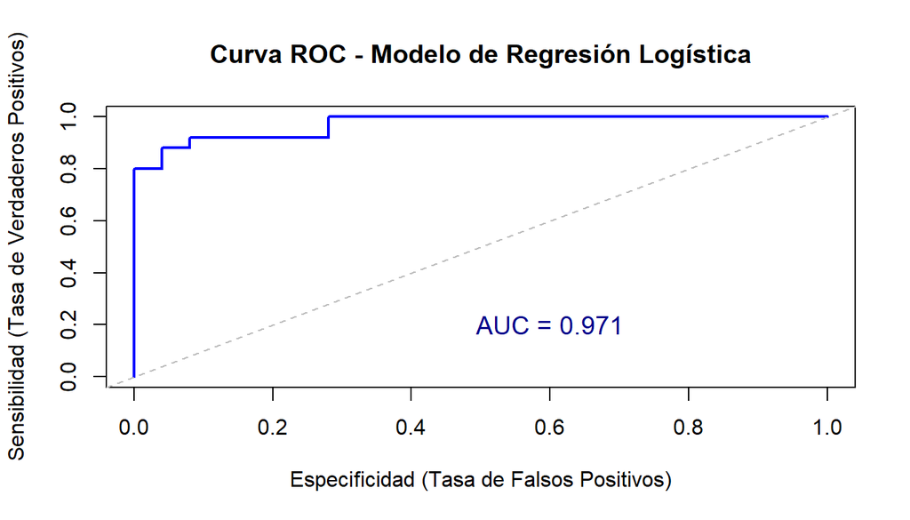

```r
text(0.6, 0.2, labels = paste("AUC =", round(auc_valor, 3)), col = "darkblue", cex = 1.2)
```

Como observación, dado que los datos de prueba tienen relativamente pocas observaciones (50), la curva no es suave, si no que más bien, escalonada con “saltos”. De todas maneras, es posible calcular el área bajo la curva (AUC) para utilizarlo como indicador de la calidad del clasificador.

# Conclusiones

Durante el desarrollo del presente trabajo, se ha trabajado con un conjunto de 507 datos de medidas de circunferencia corporal y diámetro esquelético, así como edad, peso, estatura y sexo. Se ha logrado agregar dos nuevas columnas, una para IMC que se calcula a partir del peso y la estatura, y otra para EN que es una variable categórica con dos posibles valores (“sobrepeso”, “no sobrepeso”), para la cual se creó un modelo de regresión logística que permitiría predecir la probabilidad de que ocurra el evento “sobrepeso” o “no sobrepeso”.

Luego, se realizó el proceso de toma de muestras generando dos conjuntos (únicamente de mujeres), el primero usado para la construcción/entrenamiento del modelo y el segundo utilizado para ser usado en la predicción de nuevos valores.

Se selecciona la variable Waist.Girth (circunferencia de la cintura) para utilizarla en el modelo base obteniendo un estimador de 0.44018, un z value de 4.744 y un valor p de 2.10e-06, mostrando que Waist.Girth es un predictor significativo para estimar la variable EN. También se aplica la función anova() que entrega un valor p menor a 2.2e-16 indicando el modelo de un predictor es significativamente mejor que el modelo nulo (sin predictores).

Para el paso 5 se utiliza regresión escalonada con el criterio de menor AIC, para hallar un modelo múltiple. Se obtienen los valores de los coeficientes para cada predictor resultando todos positivos, lo que indica que a mayor valor de circunferencia o diámetro de las variables, mayor será la probabilidad de que una persona pertenezca a la categoría “sobrepeso”. Las pruebas de Wald resultan no significativas para un valor alpha igual a 0.05, excepto para Chest.Girth (circunferencia del pecho), por lo que los resultados siguientes se deberán tratar con cautela. A pesar de ello, se ha logrado disminuir el valor de AIC con el nuevo modelo y su comparación frente al modelo nulo resulta significativa.

Se hizo una prueba de Pseudo R-cuadrado de McFadden obteniendo 0.632, lo cual es un buen indicador para la bondad de ajuste del conjunto de entrenamiento. Para la multicolinealidad se obtuvo valores VIF entre 1 y 1.5, que tomando un umbral de 5, indica que el modelo cumple con el supuesto de no multicolinealidad. Seguido a ello, se analizan casos sobreinfluyentes mediante la distancia de Cook resultando en 9 observaciones que superan el umbral de 4/n, lo que puede generar problemas sobre la estimación de los coeficientes del modelo. Se procede a la eliminación de outliers, haciendo nuevamente las pruebas. Pseudo R-cuadrado de McFadden aumenta a 0.862 y el AIC disminuye de 60.994 hasta 27.439, obteniendo un modelo con un ajuste superior.

Por último, al evaluar el poder predictivo de los modelos sobre los datos de prueba (muestra n=50) se obtuvo una exactitud del 88% (tasa de acierto global), una sensibilidad del 80% (el modelo fue capaz de identificar correctamente a 20 de las 25 personas que realmente pertenecían a la categoría de “sobrepeso”) y una especificidad del 96% (hubo un único falso positivo). El AUC obtenido es de 0.971, por lo que se concluye que el modelo final presenta una gran capacidad de clasificación de las observaciones.

# Referencias

Jara, J. L., & Köhler, J. (s. f.). Inferencia y modelos estadísticos [Perusall].

Heinz, G., Peterson, L. J., Johnson, R. W., & Kerk, C. J. (2003). Exploring Relationships in Body Dimensions. Journal Of Statistics Education, 11(2). https://doi.org/10.1080/10691898.2003.11910711